# Analysis: pH and O2 calculations

Source file: [SI GitHub Repository](http://www.github.com/KopfLab/2018_Silverman_et_al/) / [carbonate_chemistry.Rmd](http://www.github.com/KopfLab/2018_Silverman_et_al/blob/master/pH_O2_calculations.Rmd)

Silverman et al.

05 Jul 2018

# 1 Yield Experiment

Total growth yield of *Anabaena cylindrica* from a single headspace flush with 0.2 bar $CO_2$.

```r
OD_data <- read_excel(file.path("data", "2018_Silverman_et_al-controls_data.xlsx"), sheet = "pCO2 yield OD")

# OD yield
yield <- OD_data %>%
  filter(type == "sample") %>%
  group_by(day) %>%
  summarize(OD750 = mean(OD750)) %>%
  filter(OD750 == max(OD750))
yield
```

| day | OD750 |
| --- | --- |
| 8 | 0.4315 |

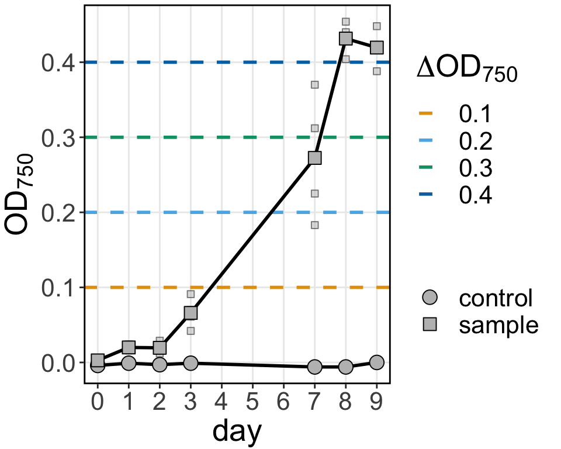

```r
# plot
OD_plot <- OD_data %>%
  ggplot() +
  # plot-wide aesthetics
  aes(x = day, y = OD750, shape = type) +
  #  OD indicator lines
  geom_hline(
    data = data_frame(D_OD = seq(0.1, 0.4, by = 0.1)),
    mapping = aes(yintercept = D_OD, color = factor(D_OD)),
    size = 1, linetype = 2
  ) +
  # all data (small translucent points)
  geom_point(size = 2, alpha = 0.5, fill = "gray") +
  # averages and lines connection them
  stat_summary(fun.y = mean, geom = "line", size = 1) +
  stat_summary(fun.y = mean, geom = "point", size = 4, fill = "gray") +
  # scale
  scale_x_continuous(breaks = 0:10) +
  scale_color_manual(values = cbPalette) +
  scale_shape_manual(values = c(21:26)) +
  # labels
  labs(x = "day", y = TeX("$OD_{750}$"),
       color = TeX("$\\Delta OD_{750}$"),
       shape = "") +
  # theme
  theme_figure()
OD_plot
```

# 2 Equations

## 2.1 Gas dissolution

$CO_2$ is moderately soluble in water forming aqueous $CO_2$ and hydrated carbonic acid with a Henry’s law constant of $K_H = 3.3 \cdot 10^{-4} \frac{mol}{m^3 Pa} = 0.033 \frac{M}{atm}$ at $T = 298.15 K$ (25C).

$O_2$ is sparingly soluble in water with a Henry’s law constant of $K_H = 1.3 \cdot 10^{-5} \frac{mol}{m^3 Pa} = 0.0013 \frac{M}{atm}$ at $T = 298.15 K$ (25C).

All constants and temperature scaling relationships for Henry’s law constants used here are from Sander, R.: Compilation of Henry’s law constants (version 4.0) for water as solvent, Atmos. Chem. Phys., 15, 4399-4981, https://doi.org/10.5194/acp-15-4399-2015, 2015.

## 2.2 Carbonate system

The carbonate system has a couple of general equilibrium equations that constrain species distribution in aqueous systems at equilibrium (assuming SPT for all stability constants):

$$\begin{aligned}
\textrm{dissociation of carbonic acid: } &
H_2CO_3^* \rightleftharpoons H^+ + HCO_3^- \\
&\textrm{with dissociation constant } \frac{[H^+][HCO_3^-]}{[H_2CO_3^*]} = K_1 = 10^{-6.3} \\
\textrm{dissociation of bicarbonate: } &
HCO_3^- \rightleftharpoons H^+ + CO_3^{2-} \\
&\textrm{with dissociation constant } \frac{[H^+][CO_3^{2-}]}{[HCO_3^-]} = K_2 = 10^{-10.3} \\
\textrm{water dissociation: } &
H_2O \rightleftharpoons H^+ + OH^- \\
&\textrm{with dissociation constant } [H^+][OH^-] = K_w = 10^{-14} \\
\textrm{dissolved inorganic carbon (DIC): } &
[DIC] = [H_2CO_3^*] + [HCO_3^-] + [CO_3^{2-}] \\
\textrm{charge balance (not considering any other solutes): } &
[H^+] - [HCO_3^-] - 2\cdot[CO_3^{2-}] - [OH^-] = 0
\end{aligned}$$

## 2.3 Charge balance

Besides the carbonate sytem, both the basicity from the addition of sodium hydroxide (adding $[Na^+]$ and $[OH^-]$ during initial pH adjustment) and any dissociated pH buffer (here the portion of the total HEPES, $[A_T]$ for short, that is dissociated into $[A^-]$ and $[H^+]$ with acid dissociation constant $K_a = \frac{[A^-][H^+]}{[AH]}$ and mass balance $[A_T] = [AH] + [A^-]$) contribute to the overall charge balance (note that the second dissociation of HEPES around pH 3 is not significant at the circumneutral pHs considered here and thus omitted for clarity):

$$[H^+] + [Na^+] - [A^-] - [HCO_3^-] - 2\cdot[HCO_3^{2-}] - [OH^-] = 0$$

Substituting in all relevant acid dissociation and gas dissolution constants ($K_x$) yields the following equation:

$$[H^+] + [Na^+] -
\frac{K_a \cdot [A_T]}{K_a+[H^+]} -
\frac{K_1 K_H \cdot P_{CO_2}}{[H^+]} -
2 \frac{K_1 K_2 K_H \cdot P_{CO_2}}{[H^+]^2} -
\frac{K_w}{[H^+]} = 0$$

## 2.4 Closed System

For a closed system such as the one used in this study (stoppered culture tubes), the mass balance based on total moles of carbon in the entire system provides an additional constraint.

### 2.4.1 Mass Balance

Total inorganic carbon ($C_T$) can be mass balanced using the ideal gas law and relevant acid dissociation and gas dissolution constants.

$$\begin{aligned}
C_{T} &= n_{CO_2(g)} + V_{liquid} \cdot DIC \\
DIC &= [H_2CO_3^*] + [HCO_3^-] + [CO_3^{2-}] = K_H \cdot P_{CO_2} \left(1 + \frac{K_1}{[H^+]} + \frac{K_1 K_2}{[H^+]^2} \right) \\
n_{CO_2(g)} &= \frac{P_{CO_2} \cdot V_{headspace}}{RT} \\
C_{T} &= P_{CO_2} \cdot \left[\frac{V_{headspace}}{RT} + V_{liquid} \cdot K_H \left( 1 + \frac{K_1}{[H^+]} + \frac{K_1 K_2}{[H^+]^2} \right) \right]
\end{aligned}$$

### 2.4.2 Final equation

With these constraints, a final equation relating pH to the added base ($[Na^+]$), total buffer ($[A_T]$), total inorganic carbon ($C_T$) and headspace + liquid volume in the system can be derived and solved for pH by standard numerical root-finding algorithms.

$$\begin{aligned}
\left[H^+\right] + [Na^+] -
\frac{K_a}{K_a+[H^+]} \cdot [A_T] -
\frac{\frac{K_1}{[H^+]} + 2\frac{K_1 K_2}{[H^+]^2}}
{\frac{V_{headspace}}{K_H\cdot RT} + \left( 1 + \frac{K_1}{[H^+]} + \frac{K_1 K_2}{[H^+]^2} \right) V_{liquid}} \cdot C_T -
\frac{K_w}{[H^+]} &= 0 \\
10^{-pH}
+ [Na^+]
- \frac{1}{1 + 10^{(pK_a-pH)}}\cdot [A_T]
- \frac{10^{(pH-pK_1)} + 2\cdot 10^{(2\cdot pH-pK_1-pK_2)}}
{\frac{V_{headspace}}{K_H\cdot RT} + \left(1 + 10^{(pH-pK_1)} + 10^{(2\cdot pH-pK_1-pK_2)}\right) V_{liquid}}
\cdot C_T
- 10^{(pH-pK_w)} &= 0
\end{aligned}$$

# 3 System

The experimental system in this study consists of 25 mL anaerobic culture tubes with 10 mL of medium initially adjusted to a pH of 7.8 in the presence of 20 mM HEPES (pKa = 7.5), and 15 mL of headspace under atmospheric $CO_2$ conditions (~400 ppm) at room temperature. Upon quick flushing of the headspace with different gas mixtures that contain 0.2 bar $CO_2$, the total inorganic carbon ($C_T$) is increased which leads to a decrease in pH. As the inorganic carbon is consumed through photosynthetic activity, the pH increases again and in parallel molecular oxygen ($O_2$) is produced with the 1:1 stoichiometry of photosynthesis ($CO_2 + H_2O \rightarrow O_2 + CH_2O$) and distributes between the liquid and gas phase according to the Henry’s law constant for $O_2$ (equations for closed system $O_2$ below). Efficient equilibration between the headspace and liquid during growth is achieved by continuous agitation. The following plots illustrate the pH and $O_2$ variations that can result after an inorganic carbon spike.

$$\begin{aligned}
O_{2(total)} &= n_{O_2(g)} + V_{liquid} \cdot [O_{2(aq)}] = \frac{P_{O_2} \cdot V_{headspace}}{RT} + K_H \cdot P_{O_2} \cdot V_{liquid} \\
\rightarrow P_{O_2} &= \frac{O_{2(total)}}{\frac{V_{headspace}}{RT} + K_H \cdot V_{liquid}}
\end{aligned}$$

```r
# calculations
plot_df <- data_frame(
  # initial conditions
  pH_init = 7.8,
  HEPES.mM = 20,
  V_liquid.mL = 10,
  V_headspace.mL = 15,
  Na_total.mM = calc_open_system_unbalanced_ions(
    pH = pH_init, pCO2.bar = 400/1e6,
    buffer.M = HEPES.mM/1e3, pKa = 7.5,
    temp.C = 22) * 1e3,
  C_init.mmol = calc_CIT_amount(
    pH = pH_init, pCO2.bar = 400/1e6,
    Vl.L = V_liquid.mL/1e3, Vg.L = V_headspace.mL/1e3,
    temp.C = 22) * 1e3,
  # carbon spike
  C_spike.mmol = calc_CO2g_amount(
    pCO2.bar = 0.2, Vg.L = V_headspace.mL/1e3, temp.C = 22) * 1e3,
  # consumption of total inorganic carbon
  C_total.mmol = seq(C_init.mmol + C_spike.mmol, 0, length.out = 20),
  # resulting pH during growth (at 27C)
  pH = calc_closed_system_pH(
    CIT.mol = C_total.mmol/1e3, Vl.L = V_liquid.mL/1e3, Vg.L = V_headspace.mL/1e3,
    buffer.M = HEPES.mM/1e3, pKa = 7.5, unbalanced_ions.M = Na_total.mM/1e3,
    temp.C = 27),
  # resulting O2 accumulation
  O2_total.mmol = C_total.mmol[1] - C_total.mmol,
  `pO2 [bar]` = calc_closed_system_pO2(
    O2_total.mol = O2_total.mmol/1e3, Vl.L = V_liquid.mL/1e3, Vg.L = V_headspace.mL/1e3, temp.C = 27)
)
plot_df
```

| pH_init | HEPES.mM | V_liquid.mL | V_headspace.mL | Na_total.mM | C_init.mmol | C_spike.mmol | C_total.mmol | pH | O2_total.mmol | pO2 [bar] |
| --- | --- | --- | --- | --- | --- | --- | --- | --- | --- | --- |
| 7.8 | 20 | 10 | 15 | 13.77928 | 0.004932174 | 0.1222488 | 0.127180925 | 7.060638 | 0.000000000 | 0.00000000 |
| 7.8 | 20 | 10 | 15 | 13.77928 | 0.004932174 | 0.1222488 | 0.120487192 | 7.089767 | 0.006693733 | 0.01090837 |
| 7.8 | 20 | 10 | 15 | 13.77928 | 0.004932174 | 0.1222488 | 0.113793459 | 7.119879 | 0.013387466 | 0.02181674 |
| 7.8 | 20 | 10 | 15 | 13.77928 | 0.004932174 | 0.1222488 | 0.107099726 | 7.151066 | 0.020081199 | 0.03272510 |
| 7.8 | 20 | 10 | 15 | 13.77928 | 0.004932174 | 0.1222488 | 0.100405994 | 7.183348 | 0.026774932 | 0.04363347 |
| 7.8 | 20 | 10 | 15 | 13.77928 | 0.004932174 | 0.1222488 | 0.093712261 | 7.216786 | 0.033468665 | 0.05454184 |
| 7.8 | 20 | 10 | 15 | 13.77928 | 0.004932174 | 0.1222488 | 0.087018528 | 7.251374 | 0.040162397 | 0.06545021 |
| 7.8 | 20 | 10 | 15 | 13.77928 | 0.004932174 | 0.1222488 | 0.080324795 | 7.287155 | 0.046856130 | 0.07635857 |
| 7.8 | 20 | 10 | 15 | 13.77928 | 0.004932174 | 0.1222488 | 0.073631062 | 7.324169 | 0.053549863 | 0.08726694 |
| 7.8 | 20 | 10 | 15 | 13.77928 | 0.004932174 | 0.1222488 | 0.066937329 | 7.362447 | 0.060243596 | 0.09817531 |

[output cut: 10 more lines]

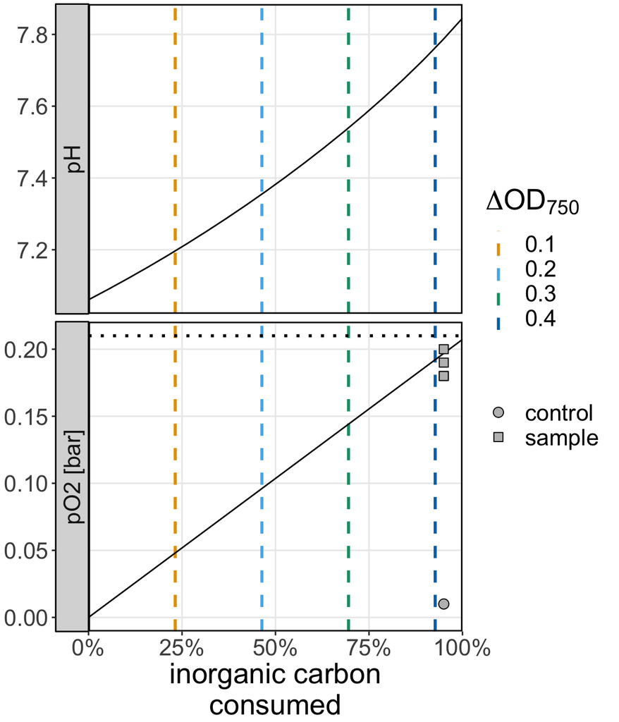

```r
# O2 data
O2_data <-
  read_excel(
    file.path("data", "2018_Silverman_et_al-controls_data.xlsx"),
    sheet = "pCO2 yield O2") %>%
  gather(var, val, `pO2 [bar]`)

# plot
pH_O2_plot <- plot_df %>%
  gather(var, val, pH, `pO2 [bar]`) %>%
  ggplot() +
  aes(1-C_total.mmol/C_total.mmol[1], val) +
  # OD indicators
  geom_vline(
    data = data_frame(
      D_OD = seq(0.1, 0.4, by = 0.1),
      C_percent = D_OD / yield$OD750),
    mapping = aes(xintercept = C_percent, color = factor(D_OD)),
    size = 1, linetype = 2
  ) +
  # atmospheric oxygen line
  geom_hline(
    data = data_frame(y = 0.21, var = "pO2 [bar]"),
    mapping = aes(yintercept = y), size = 1, linetype = 3
  ) +
  # model line
  geom_line() +
  # O2 data points
  geom_point(data = O2_data, mapping = aes(x = 0.95, shape = type),
             fill = "gray", size = 3) +
  # scales
  scale_x_continuous("inorganic carbon\nconsumed",
                     labels = scales::percent, expand = c(0,0)) +
  scale_color_manual(values = cbPalette) +
  scale_shape_manual(values = c(21:26)) +
  facet_grid(var~., scales = "free_y", switch = "y") +
  theme_figure() +
  labs(y=NULL, color = TeX("$\\Delta OD_{750}$"), shape = "")
pH_O2_plot
```

## 3.1 Combined Plot

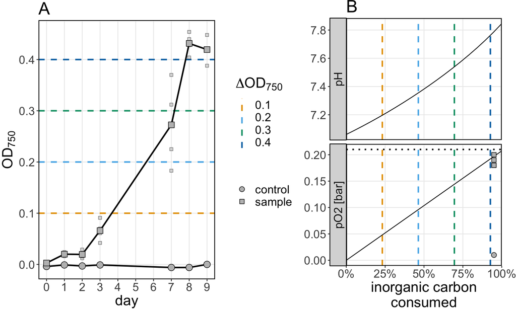

```r
grid.arrange(
  OD_plot + labs(title = "A") +
    theme(legend.position = "none"),
  pH_O2_plot + labs(title = "B") +
    theme(legend.position = "left", plot.margin = margin(r = 20, l = 15)),
  ncol = 2, widths = c(3, 4))
```